# The Numbers of Music:

### A Short History of Music, as told by the Billboard Hot 100 - Introduction and Background

Music has been a meaningful part of all cultures for thousands of years, but the concept of rating music is relatively new. Since the late 1950s, Billboard has been tracking and ranking the popularity of music leading to a large, quantifiable dataset. With the power of modern data science, it is easy to analyze and identify trends in big data. With some modern songs spending a surprisingly long amount of time on the charts, we began to wonder if there was a correlation between when certain top songs were released and how long they stayed popular as quantified by music charts like the Billboard Top 100. We hypothesized that as time progressed newer songs would, in general, spend more time and remain in higher positions on the charts due to factors such as increasing access to music through online distribution and the greater incorporation of popular songs in media such as in sports or in advertising. By finding trends in the Billboard Top 100 charts such as the number of weeks popular songs and artists spent at the number one position and their positions on the chart over time, we hope to be able to show that as music approached the current day, these factors would trend upwards, with newer hit songs and their artists staying at number 1 and on the chart for a longer period of time and staying in a higher position overall in comparison to their older counterparts before completely dropping out of the chart.

## Privacy/Ethics Considerations

In terms of privacy, our data is taken from a publicly available source here and so there were not too many considerations for us to take in this aspect. One thing to consider is that our data might not be entirely objective. Billboard has their own internal methods of classifying and ranking songs on their Top 100 chart which have not been made known to the public. Due to the secrecy behind their methods it is difficult to know the validity of their rankings. However, taking into account widespread media acknowledgement and the overall reputation of Billboard, we can see that each Top 100 chart is reflective of the general music trends for each of their respective weeks.

## Data Description

Our data was taken from the Billboard Top 100 website using the billboard.py API which can be found [here](https://github.com/guoguo12/billboard-charts). Using the API, we were able to get every Billboard Top 100 chart from mid-1958 until February 2018. Once all of these charts were retrieved, we extracted them into .json files using the merge_json.py script which can be found in our GitHub repository [here](https://github.com/COGS108/Pr_089/blob/master/merge_json.py). Using this data, we began to look for statistics regarding the Billboard Top 100 such as which artists had the most top 10 appearances on the chart and the positions of popular songs over each decade from the 1950s until today over their entire Billboard lifespans.

### Interactivity Side Note

Most of our data has been saved to be displayed statically, but if anyone is interested in playing around with our data set, feel free to check out our *Interactive Graph Plotting* section after running all prior cells in order.

## Data Cleaning and Pre-Processing

As mentioned earlier, our data was grabbed from the Billboard Hot 100. There were two methods of doing this. One method was to download full HTML pages and use BeautifulSoup to parse and extract the Hot 100, and the other was to use the billboard.py API. Since dealing with raw HTML is quite rough, we opted to go with the API.

Though the API was a lot more convenient, it brought up the issue of not giving us a file to use. To combat this, we wrote the script `save_chart_as_json.py`, which downloads all of the charts, adds them to a huge dict, then serializes that dict into a .json file.

We ran into a couple issues with this script. Firstly, for some unknown reason, the program wouldn’t download every single chart and would cut off at a specific date. To combat this, the script was modified to save that first section into a .json file, then to start again from where it left off and save the rest of the data into a second .json file.

Now, we had to merge and verify the .json files. For this, two scripts were written: `merge_json.py` and `print_json.py`. The former took the two .json files and merged them into a file called full_data.json. The latter could be used to print out the .json files in a more legible format than one would get from simply using a command like `cat`, `more`, or `less`.

Finally, we could start to clean our data. Luckily, since Billboard keeps their records essentially immaculate, there wasn’t too much to do here. Firstly, we read in the data into a DataFrame, but found that the formatting that was easiest for serializing was the worst for usage. Each song entry was a list with 5 entries, and a full chart took up a row, giving us 3,108 rows and 100 columns. A more optimal DataFrame for usage would have each song take up a row and each attribute be a column (giving 7 columns). Before doing that, we had to deal with NaN values; only 126 individual entries out of 310,800 songs were NaN, so for those we did simple replacement to fill them in with -1 (since -1 is a value that won’t naturally occur in the charts).

Next up was extraction. To accomplish this, a code block populates lists with one containing numbers 1-100 (for re-numbering), 1-3,108 for keeping the current valid chart week, then lists with all of the Song Names, peak positions, last positions, artist, and number of weeks on the chart. This reshaped our DataFrame from being 3,108 rows by 100 columns to being 310,800 rows by 7 columns, and with this DataFrame we were able to do all of our analysis.

### Imports

```python
# Imports for the project

%matplotlib inline

import pandas as pd
import numpy as np
import matplotlib.pyplot as plt
from sys import stdout as std
```

### Cleanup Part 1 – Getting the Data

First up: Reading in the data and examining the first sections of it to make sure all is well.

```python
# Read in the data into DataFrames to start our analysis


df2 = pd.read_json('./full_data.json')
```

```python
# Now, let's sort this data to get it formatted where each row is a full chart and each entry is a
# list of attributes relating to the song at that position


sort_mod_df = df2.reindex_axis(sorted(df2.columns), axis=1)

# Let's examine the dataframe
sort_mod_df.head()
```

|  | 1 | 2 | 3 | 4 | 5 | 6 | 7 | 8 | 9 | 10 | ... | 91 | 92 | 93 | 94 | 95 | 96 | 97 | 98 | 99 | 100 |
| --- | --- | --- | --- | --- | --- | --- | --- | --- | --- | --- | --- | --- | --- | --- | --- | --- | --- | --- | --- | --- | --- |
| 0 | [God's Plan, Drake, 1, 1, 4] | [Perfect, Ed Sheeran, 1, 2, 25] | [Finesse, Bruno Mars & Cardi B, 3, 3, 7] | [Havana, Camila Cabello Featuring Young Thug, ... | [Rockstar, Post Malone Featuring 21 Savage, 1,... | [Look Alive, BlocBoy JB Featuring Drake, 6, 0, 1] | [Meant To Be, Bebe Rexha & Florida Georgia Lin... | [New Rules, Dua Lipa, 6, 6, 29] | [All The Stars, Kendrick Lamar & SZA, 9, 31, 6] | [Stir Fry, Migos, 8, 8, 8] | ... | [Black Panther, Kendrick Lamar, 91, 0, 1] | [At The Club, Jacquees X Dej Loaf, 92, 92, 2] | [Codeine Dreaming, Kodak Black Featuring Lil W... | [The Long Way, Brett Eldredge, 93, 93, 2] | [Rock, Plies, 95, 99, 3] | [I Like Me Better, Lauv, 96, 0, 1] | [When We, Tank, 86, 0, 7] | [Criminal, Natti Natasha x Ozuna, 95, 95, 3] | [IDGAF, Dua Lipa, 88, 88, 5] | [Rewrite The Stars, Zac Efron & Zendaya, 70, 8... |
| 1 | [God's Plan, Drake, 1, 1, 3] | [Perfect, Ed Sheeran, 1, 2, 24] | [Finesse, Bruno Mars & Cardi B, 3, 3, 6] | [Havana, Camila Cabello Featuring Young Thug, ... | [Rockstar, Post Malone Featuring 21 Savage, 1,... | [New Rules, Dua Lipa, 6, 7, 28] | [Pray For Me, The Weeknd & Kendrick Lamar, 7, ... | [Stir Fry, Migos, 8, 12, 7] | [Meant To Be, Bebe Rexha & Florida Georgia Lin... | [Bad At Love, Halsey, 5, 6, 23] | ... | [Mayores, Becky G Featuring Bad Bunny, 74, 95,... | [At The Club, Jacquees X Dej Loaf, 92, 0, 1] | [The Long Way, Brett Eldredge, 93, 0, 1] | [Singles You Up, Jordan Davis, 94, 0, 1] | [Criminal, Natti Natasha x Ozuna, 95, 0, 2] | [Corazon, Maluma X Nego do Borel, 87, 100, 6] | [Sick Boy, The Chainsmokers, 65, 90, 3] | [A Girl Like You, Easton Corbin, 98, 0, 1] | [Rock, Plies, 99, 0, 2] | [Supplies, Justin Timberlake, 71, 0, 2] |
| 2 | [God's Plan, Drake, 1, 1, 2] | [Perfect, Ed Sheeran, 1, 2, 23] | [Finesse, Bruno Mars & Cardi B, 3, 5, 5] | [Havana, Camila Cabello Featuring Young Thug, ... | [Rockstar, Post Malone Featuring 21 Savage, 1,... | [Bad At Love, Halsey, 5, 6, 22] | [New Rules, Dua Lipa, 7, 8, 27] | [MotorSport, Migos, Nicki Minaj & Cardi B, 6, ... | [Say Something, Justin Timberlake Featuring Ch... | [Thunder, Imagine Dragons, 4, 9, 40] | ... | [Rubbin Off The Paint, YBN Nahmir, 46, 69, 13] | [El Farsante, Ozuna & Romeo Santos, 92, 0, 1] | [IDGAF, Dua Lipa, 92, 92, 3] | [Most People Are Good, Luke Bryan, 94, 0, 1] | [Mayores, Becky G Featuring Bad Bunny, 74, 94,... | [CC, Migos Featuring Gucci Mane, 96, 0, 1] | [Best Friend, Sofi Tukker Featuring NERVO, The... | [MIC Drop, BTS Featuring Desiigner, 28, 84, 10] | [King's Dead, Jay Rock, Kendrick Lamar, Future... | [Corazon, Maluma X Nego do Borel, 87, 93, 5] |
| 3 | [God's Plan, Drake, 1, 0, 1] | [Perfect, Ed Sheeran, 1, 2, 22] | [Havana, Camila Cabello Featuring Young Thug, ... | [Rockstar, Post Malone Featuring 21 Savage, 1,... | [Finesse, Bruno Mars & Cardi B, 3, 4, 4] | [Bad At Love, Halsey, 5, 5, 21] | [Diplomatic Immunity, Drake, 7, 0, 1] | [New Rules, Dua Lipa, 8, 8, 26] | [Thunder, Imagine Dragons, 4, 6, 39] | [No Limit, G-Eazy Featuring A$AP Rocky & Cardi... | ... | [Beautiful Trauma, P!nk, 91, 99, 5] | [IDGAF, Dua Lipa, 92, 92, 2] | [Corazon, Maluma X Nego do Borel, 87, 87, 4] | [Mayores, Becky G Featuring Bad Bunny, 74, 93,... | [The Greatest Show, Hugh Jackman, Keala Settle... | [Never Enough, Loren Allred, 88, 97, 4] | [My Dawg, Lil Baby, 71, 90, 7] | [I'll Name The Dogs, Blake Shelton, 56, 82, 20] | [Rock, Plies, 99, 0, 1] | [Female, Keith Urban, 69, 100, 5] |
| 4 | [Havana, Camila Cabello Featuring Young Thug, ... | [Perfect, Ed Sheeran, 1, 1, 21] | [Rockstar, Post Malone Featuring 21 Savage, 1,... | [Finesse, Bruno Mars & Cardi B, 3, 3, 3] | [Bad At Love, Halsey, 5, 7, 20] | [Thunder, Imagine Dragons, 4, 6, 38] | [No Limit, G-Eazy Featuring A$AP Rocky & Cardi... | [New Rules, Dua Lipa, 8, 11, 25] | [Too Good At Goodbyes, Sam Smith, 4, 8, 19] | [MotorSport, Migos, Nicki Minaj & Cardi B, 6, ... | ... | [King's Dead, Jay Rock, Kendrick Lamar, Future... | [IDGAF, Dua Lipa, 92, 0, 1] | [Mayores, Becky G Featuring Bad Bunny, 74, 94,... | [Broken Halos, Chris Stapleton, 90, 91, 8] | [Krippy Kush, Farruko, Nicki Minaj, Bad Bunny,... | [...Ready For It?, Taylor Swift, 4, 80, 20] | [Never Enough, Loren Allred, 88, 99, 3] | [El Bano, Enrique Iglesias Featuring Bad Bunny... | [Beautiful Trauma, P!nk, 95, 95, 4] | [Female, Keith Urban, 69, 96, 4] |

5 rows × 100 columns

### Cleanup Part 2 – Reorganizing our Data

We have our song data! Now to extract and clean it up a bit. Though the above format makes it pretty easy to track a particular song over the chart, we also want to separate each attribute so that we can grab particular portions of our data more easily.

To do this, we'll want to change the columns to represent a specific attribute of the chart. Currently, each chart takes up a full row where each columns is the particular rank of a song in that chart, but we're going to change the shape so that there will be 7 columns instead of 100, with 310,800 rows instead of 3,108.

```python
# Save the current chart week numbers in a list for restoration later

SongWeeks = []
curr_pos = []
for num in range(len(sort_mod_df)):

    SongWeeks.append(num)

for num in range(1, 101):
    curr_pos.append(num)
```

```python
# Let's now see how many entries are blank in our data
n_nan = sort_mod_df.isnull().sum()
n_nan = sum(n_nan)
print(n_nan)
```

```
126
```

```python
# Replae NaN entries with a default value
sort_mod_df.fillna(-1, inplace=True)
```

```python
# Verify that blank entries are gone
n_nan = sort_mod_df.isnull().sum()
n_nan = sum(n_nan)
print(n_nan)
```

```
0
```

### Cleanup Part 3 – Putting it All Together

The next section separates out each entry of the DataFrame, organizing it into lists. Then, those lists are turned into Pandas Series objects and combined into a cleaned out DataFrame with the desired shape.

```python
# Next, put all of the song attributes into separate lists to use as columns

# Create the lists
SongName = []
Artist = []
PeakPos = []
LastPos = []
NumWeeks = []

# Iterate through the entire dataframe
for index, series in sort_mod_df.iterrows():

    # Grab particular entries from the current row
    for entry in series:

        # Handle case of missing data
        if entry == -1:
            nm = entry
            NumWeeks.append(nm)
            LastPos.append(nm)
            PeakPos.append(nm)
            Artist.append(nm)
            SongName.append(nm)
        else:
            for i in range(0, 5):
                nm = entry.pop()
                if i == 0:
                    NumWeeks.append(nm)
                elif i == 1:
                    LastPos.append(nm)
                elif i == 2:
                    PeakPos.append(nm)
                elif i == 3:
                    Artist.append(nm)
                elif i == 4:
                    SongName.append(nm)
```

```python
# Delete the copy dataframe. It's all empty now, anyway
try:

    del sort_mod_df
except(NameError):
    pass

# Now, let's build a nicely cleaned dataframe

# Use a list comprehension to extend out our SongWeeks list
new_SongWeeks = [item for item in SongWeeks for i in range(100)]

# Use a list comprehension to extend the 1-100 list
new_currPos = [num for i in range(len(SongWeeks)) for num in curr_pos]

# Make our empty DataFrame
sep_df = pd.DataFrame()

# Make each list into a series
col0 = pd.Series(data=new_SongWeeks)
col1 = pd.Series(data=SongName)
col2 = pd.Series(data=Artist)
col3 = pd.Series(data=PeakPos)
col4 = pd.Series(data=LastPos)
col5 = pd.Series(data=NumWeeks)
col6 = pd.Series(data=new_currPos)

# Add each series to the DataFrame
sep_df['Week of Chart'] = col0.values
sep_df['Current Position'] = col6.values
sep_df['Song Name'] = col1.values
sep_df['Artist'] = col2.values
sep_df['Peak Position'] = col3.values
sep_df['Last Position'] = col4.values
sep_df['Number of Weeks'] = col5.values


# Examine our new DataFrame
print(sep_df.shape)
sep_df.head(10)
```

```
(310800, 7)
```

|  | Week of Chart | Current Position | Song Name | Artist | Peak Position | Last Position | Number of Weeks |
| --- | --- | --- | --- | --- | --- | --- | --- |
| 0 | 0 | 1 | God's Plan | Drake | 1 | 1 | 4 |
| 1 | 0 | 2 | Perfect | Ed Sheeran | 1 | 2 | 25 |
| 2 | 0 | 3 | Finesse | Bruno Mars & Cardi B | 3 | 3 | 7 |
| 3 | 0 | 4 | Havana | Camila Cabello Featuring Young Thug | 1 | 4 | 27 |
| 4 | 0 | 5 | Rockstar | Post Malone Featuring 21 Savage | 1 | 5 | 22 |
| 5 | 0 | 6 | Look Alive | BlocBoy JB Featuring Drake | 6 | 0 | 1 |
| 6 | 0 | 7 | Meant To Be | Bebe Rexha & Florida Georgia Line | 7 | 9 | 17 |
| 7 | 0 | 8 | New Rules | Dua Lipa | 6 | 6 | 29 |
| 8 | 0 | 9 | All The Stars | Kendrick Lamar & SZA | 9 | 31 | 6 |
| 9 | 0 | 10 | Stir Fry | Migos | 8 | 8 | 8 |

In this new DataFrame, the "Week of Chart" column refers to how many weeks prior to 24 February 2018 that particular chart is, with 24 February 2018 being the date of the first chart we downloaded. Therefore, *the older the chart, the larger the number.*

Now that we have our nicely sorted and cleaned data, let's start analyzing it to see what trends and patterns we can find.

# Data Visualization, Analysis, and Results

## Finding the Song with the Longest Time

First, let's check out staying power. Often, people use the amount of time on the charts as a measurement of how good a song is. The better the song, the more weeks it is able to hold a chart spot. However, this is only part of the story; a song that holds spot No. 76 is unlikely to garner as much attention as the top 10 or top 5 songs. So, let's compare all of the songs that have reached the top 5 and see who has been there the longest

```python
# Separate out all the songs that reached the top 5 (All songs with 5 or less in their peak position column)

top_df = sep_df.loc[(sep_df['Peak Position'] <= 5) & (sep_df['Peak Position'] != -1)]
top_df.head(10)
```

|  | Week of Chart | Current Position | Song Name | Artist | Peak Position | Last Position | Number of Weeks |
| --- | --- | --- | --- | --- | --- | --- | --- |
| 0 | 0 | 1 | God's Plan | Drake | 1 | 1 | 4 |
| 1 | 0 | 2 | Perfect | Ed Sheeran | 1 | 2 | 25 |
| 2 | 0 | 3 | Finesse | Bruno Mars & Cardi B | 3 | 3 | 7 |
| 3 | 0 | 4 | Havana | Camila Cabello Featuring Young Thug | 1 | 4 | 27 |
| 4 | 0 | 5 | Rockstar | Post Malone Featuring 21 Savage | 1 | 5 | 22 |
| 14 | 0 | 15 | Thunder | Imagine Dragons | 4 | 11 | 42 |
| 15 | 0 | 16 | Bad At Love | Halsey | 5 | 10 | 24 |
| 19 | 0 | 20 | No Limit | G-Eazy Featuring A$AP Rocky & Cardi B | 4 | 16 | 23 |
| 23 | 0 | 24 | Shape Of You | Ed Sheeran | 1 | 23 | 58 |
| 24 | 0 | 25 | Bodak Yellow (Money Moves) | Cardi B | 1 | 19 | 33 |

So, ignoring the very first chart (3107) and the most recent one we downloaded (0), which song has the most amount of time spent on the hot 100?

```python
top_df.loc[top_df['Number of Weeks'].idxmax()]
```

```
Week of Chart                   199
Current Position                 49
Song Name               Radioactive
Artist              Imagine Dragons
Peak Position                     3
Last Position                    48
Number of Weeks                  87
Name: 19948, dtype: object
```

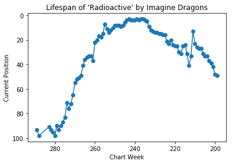

```python
# First, let's grab the relevant data
rdact = sep_df.loc[(sep_df['Song Name'] == "Radioactive") & (sep_df['Artist'] == 'Imagine Dragons')]

# Now, graph the data with the Current Position on the Y axis and the Week of Chart on the X axis
x = rdact['Week of Chart']
y = rdact['Current Position']
plt.plot(x, y, '-o')

# Label the axes
plt.xlabel('Chart Week')
plt.ylabel('Current Position')

# Add a title
plt.title("Lifespan of 'Radioactive' by Imagine Dragons")

# We're inverting the axes for a more intuitive feel. This way, the passage of time
# goes left to right, and the more popular the song, the higher it is on the graph
# Each dot represents a different week's chart
plt.gca().invert_xaxis()
plt.gca().invert_yaxis()
plt.show()
```

## Finding Artists with the Most Appearances

Individual time spent on the charts for a single song is one way to measure the popularity of a song, but for an artist, in general, it's often better to look at the amount of times that they have a song that appears on the charts. Let's see the top 10 artists with the most Billboard chart appearances.

```python
%%time

# Create a dict of values where key = artist name, value = number of appearances
most = {}

# Iterate through our dataframe
for index, series in sep_df.iterrows():

    # Grab name of artist for the current row
    curr = series['Artist']

    # If the artist isn't already in the dict, add them
    if curr not in most.keys():

        most[curr] = 1

    # They are there, so increment their number
    else:

        num = most.get(curr)
        num += 1
        most[curr] = num
```

```
CPU times: user 18.7 s, sys: 68.3 ms, total: 18.8 s
Wall time: 19 s
```

Now, let's display the results in a bar graph.

### **NOTE**: Do *not* run the cell directly below this one more than one time per instance of the current kernel! Doing so *will cause errors* with the output!

```python
# Create lists to store relevant top 10 data
top10_songs = []
top10_artists = []

# Grab the top 10, in order from 1-10
for num in range(10):

    # Grab the key with the highest corresponding max value entry
    max_value = max(most.keys(), key=lambda k: most[k])

    # Add the key to the artists list
    top10_artists.append(max_value)

    # Add the number of appearances to the other list
    top10_songs.append(most.get(max_value))

    # Delete the value to find the next highest
    del most[max_value]
```

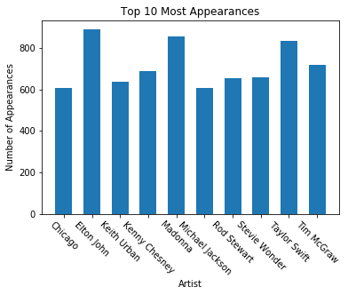

```python
# Plot the top 10
plt.bar(top10_artists, top10_songs, width=0.6)

# Add x axis label
plt.xlabel('Artist')

# Rotate the names to be more readable
plt.xticks(rotation=-45)

# Add y axis label
plt.ylabel('Number of Appearances')

# Add graph title
plt.title("Top 10 Most Appearances")
plt.show()
```

## Interactive Graph Plotting

To get a better intuition as to how time has changed the life spans of songs on the Billboard charts, we can try to graph multiple songs. Rather than hard code which values appear, we've made an interactive section which allows *you*, the user, to find songs and display a life cycle graph for the song chosen. This next block defines the functions that get called by the interactive script section.

```python
"""
Takes in the user inputted artist name and returns a DataFrame of all of the
number 1 hits for that artist

Params: artist: The artist name to search for
        option: boolean value for determining if searching for No. 1's exclusively
Return: A DataFrame of number 1 hits for an artist, cleaned up. If artist
has no number 1 hits/no songs on any charts, an empty DataFrame is returned
"""
def find_no_1s(artist, option):

    # Determine if user wants to grab from just the number 1 songs or all of the songs
    if option == True:
        number1s = sep_df.loc[(sep_df['Peak Position'] == 1) & (sep_df['Artist'] == artist)]
    else:
        number1s = sep_df.loc[sep_df['Artist'] == artist]


    number1s.drop_duplicates(['Song Name'], keep='last', inplace=True)
    number1s.reset_index(inplace=True)
    return number1s

"""
Takes in a name of a song and an artist name, creates a DataFrame for that artist/song pair,
builds a graph of that relationship, then returns that graph for plotting.

Params: songname: The song title to search for
        artist: The artist name to search for
Return: A graph of the lifespan of the given song
"""
def display_results(songname, artist):

    # First, let's grab the relevant data
    rdact = sep_df.loc[(sep_df['Song Name'] == songname) & (sep_df['Artist'] == artist)]

    # Now, graph the data with the Current Position on the Y axis and the Week of Chart on the X axis
    x = rdact['Week of Chart']
    y = rdact['Current Position']
    plt.plot(x, y, '-o')

    # Add labels and a title
    plt.xlabel('Chart Week')
    title_string = "Lifespan of '" + songname + "' by " + artist
    plt.title(title_string)
    plt.ylabel('Current Position')

    # Invert axes for same reason as abovee
    plt.gca().invert_xaxis()
    plt.gca().invert_yaxis()

    return plt
```

Now, let's set up the environment for the user to interact with the above functions.

```
Select if you want to search only number 1 hits (T), or all hits (F): T
Please enter an artist to search for (including 'Featuring' if you want features). Type 'Q' to quit: Ray Charles
```

```
Your artist's No. 1 hits are:
0    I Can't Stop Loving You
1         Georgia On My Mind
Name: Song Name, dtype: object
Please type the name of a song from the list below to search for: Georgia On My Mind
```

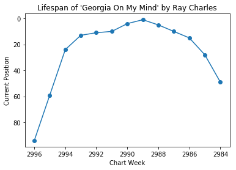

```
Select if you want to search only number 1 hits (T), or all hits (F): T
Please enter an artist to search for (including 'Featuring' if you want features). Type 'Q' to quit: The Beatles

Your artist's No. 1 hits are:
0     The Long And Winding Road/For You Blue
1                                  Let It Be
2                    Come Together/Something
3                                   Hey Jude
4                              Hello Goodbye
5                       All You Need Is Love
6                                 Penny Lane
7                           Paperback Writer
8                         We Can Work It Out
9                                  Yesterday
10                                     Help!
11                            Ticket To Ride
12                         Eight Days A Week
13                               I Feel Fine
14                        A Hard Day's Night
15                                Love Me Do
16                         Can't Buy Me Love
17                             She Loves You
18                  I Want To Hold Your Hand
Name: Song Name, dtype: object
Please type the name of a song from the list below to search for: Hey Jude
```

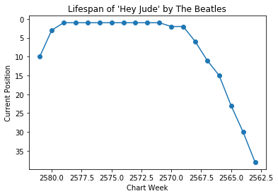

```
Select if you want to search only number 1 hits (T), or all hits (F): T
Please enter an artist to search for (including 'Featuring' if you want features). Type 'Q' to quit: The Supremes

Your artist's No. 1 hits are:
0                       The Happening
1    Love Is Here And Now You're Gone
2              You Keep Me Hangin' On
3                You Can't Hurry Love
4                   I Hear A Symphony
5               Back In My Arms Again
6           Stop! In The Name Of Love
7                   Come See About Me
8                           Baby Love
9               Where Did Our Love Go
Name: Song Name, dtype: object
Please type the name of a song from the list below to search for: Back In My Arms Again
```

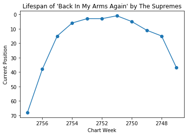

```
Select if you want to search only number 1 hits (T), or all hits (F): T
Please enter an artist to search for (including 'Featuring' if you want features). Type 'Q' to quit: Jackson 5

Your artist's No. 1 hits are:
0                          I'll Be There
1    The Love You Save/I Found That Girl
2                                    ABC
3                        I Want You Back
Name: Song Name, dtype: object
Please type the name of a song from the list below to search for: I'll Be There
```

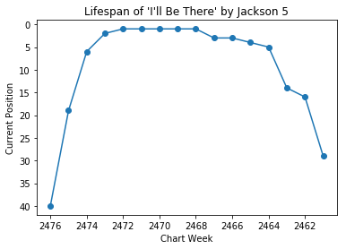

```
Select if you want to search only number 1 hits (T), or all hits (F): T
Please enter an artist to search for (including 'Featuring' if you want features). Type 'Q' to quit: Earth, Wind & Fire

Your artist's No. 1 hits are:
0    Shining Star
Name: Song Name, dtype: object
Please type the name of a song from the list below to search for: Shining Star
```

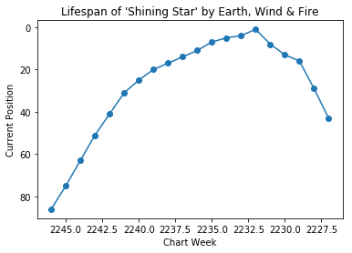

```
Select if you want to search only number 1 hits (T), or all hits (F): T
Please enter an artist to search for (including 'Featuring' if you want features). Type 'Q' to quit: David Bowie

Your artist's No. 1 hits are:
0    Let's Dance
1           Fame
Name: Song Name, dtype: object
Please type the name of a song from the list below to search for: Let's Dance
```

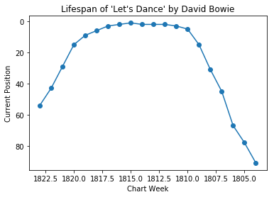

```
Select if you want to search only number 1 hits (T), or all hits (F): T
Please enter an artist to search for (including 'Featuring' if you want features). Type 'Q' to quit: Michael Jackson

Your artist's No. 1 hits are:
0                  You Are Not Alone
1                     Black Or White
2                        Dirty Diana
3                  Man In The Mirror
4           The Way You Make Me Feel
5                                Bad
6                            Beat It
7                        Billie Jean
8                      Rock With You
9     Don't Stop 'til You Get Enough
10                               Ben
Name: Song Name, dtype: object
Please type the name of a song from the list below to search for: Rock With You
```

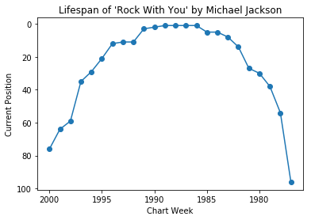

```
Select if you want to search only number 1 hits (T), or all hits (F): T
Please enter an artist to search for (including 'Featuring' if you want features). Type 'Q' to quit: George Michael

Your artist's No. 1 hits are:
0    Praying For Time
1              Monkey
2        One More Try
3       Father Figure
4               Faith
Name: Song Name, dtype: object
Please type the name of a song from the list below to search for: One More Try
```

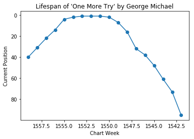

```
Select if you want to search only number 1 hits (T), or all hits (F): T
Please enter an artist to search for (including 'Featuring' if you want features). Type 'Q' to quit: Wham!

Your artist's No. 1 hits are:
0           Everything She Wants
1    Wake Me Up Before You Go-Go
Name: Song Name, dtype: object
Please type the name of a song from the list below to search for: Wake Me Up Before You Go-Go
```

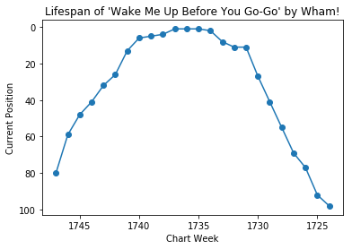

```
Select if you want to search only number 1 hits (T), or all hits (F): T
Please enter an artist to search for (including 'Featuring' if you want features). Type 'Q' to quit: Madonna

Your artist's No. 1 hits are:
0                             Music
1                        Take A Bow
2     This Used To Be My Playground
3                   Justify My Love
4                             Vogue
5                     Like A Prayer
6                   Who's That Girl
7                   Open Your Heart
8                 Papa Don't Preach
9                      Live To Tell
10                    Crazy For You
11                    Like A Virgin
Name: Song Name, dtype: object
Please type the name of a song from the list below to search for: This Used To Be My Playground
```

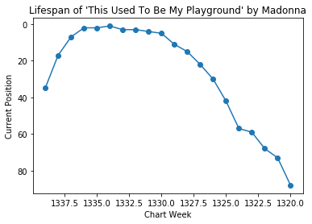

```
Select if you want to search only number 1 hits (T), or all hits (F): T
Please enter an artist to search for (including 'Featuring' if you want features). Type 'Q' to quit: Boyz II Men

Your artist's No. 1 hits are:
0               4 Seasons Of Loneliness
1                        On Bended Knee
2                 I'll Make Love To You
3    End Of The Road (From "Boomerang")
Name: Song Name, dtype: object
Please type the name of a song from the list below to search for: I'll Make Love To You
```

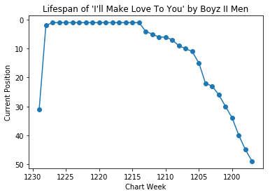

```
Select if you want to search only number 1 hits (T), or all hits (F): T
Please enter an artist to search for (including 'Featuring' if you want features). Type 'Q' to quit: Stevie B

Your artist's No. 1 hits are:
0    Because I Love You (The Postman Song)
Name: Song Name, dtype: object
Please type the name of a song from the list below to search for: Because I Love You
Song name 'Because I Love You' not valid, try again
Select if you want to search only number 1 hits (T), or all hits (F): T
Please enter an artist to search for (including 'Featuring' if you want features). Type 'Q' to quit: Stevie B

Your artist's No. 1 hits are:
0    Because I Love You (The Postman Song)
Name: Song Name, dtype: object
Please type the name of a song from the list below to search for: Because I Love You (The Postman Song)
```

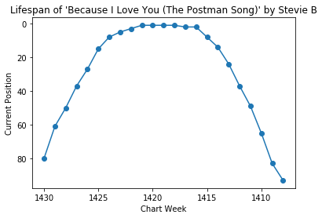

```
Select if you want to search only number 1 hits (T), or all hits (F): T
Please enter an artist to search for (including 'Featuring' if you want features). Type 'Q' to quit: Mariah Carey

Your artist's No. 1 hits are:
0             Touch My Body
1     Don't Forget About Us
2        We Belong Together
3                    My All
4                     Honey
5         Always Be My Baby
6                   Fantasy
7                      Hero
8                Dreamlover
9             I'll Be There
10                 Emotions
11        I Don't Wanna Cry
12                  Someday
13          Love Takes Time
14           Vision Of Love
Name: Song Name, dtype: object
Please type the name of a song from the list below to search for: We Belong Together
```

[6 more figures not shown]

```python
# Create an interactive graph plotting section where users can see the lifespan of different songs
# using the above functions.

try:

    while True:

        option = False

         # Let user decide if they want to search just number 1 options, or all options
        usr_input = input("Select if you want to search only number 1 hits (T), or all hits (F): ")

        # Parse entered option
        if usr_input.upper() == 'T':

            option = True
        elif usr_input.upper() == 'F':
            option = False

        # Invalid option; treat as a quit signal
        else:
            raise KeyboardInterrupt


        # Output the prompt and grab the user's input
        std.write("Please enter an artist to search for (including 'Featuring' if you want features). ")
        std.write('Type \'Q\' to quit: ')
        to_search = input()
        print()

        # Verify that they don't want to end the program
        if to_search.upper() == 'Q':
            raise KeyboardInterrupt

        # Call function to get the dataframe
        result = find_no_1s(to_search, option)

        # Make sure the dataframe has entries
        if(len(result) == 0):

            print("ERROR: artist entered with no hits")
            continue


        # Report matches to the user
        if option == True:
            print("Your artist's No. 1 hits are: \n%s" % repr(result['Song Name']))
        else:
            print("Your artist's chart hits are: \n%s" % repr(result['Song Name']))

        # Grab the song name
        item = input("Please type the name of a song from the list below to search for: ")

        # Initialize the boolean value
        exists = False

        # Iterate through the returned dataframe
        for ind, ser in result.iterrows():

            if item == ser['Song Name']:
                exists = True

        # Make sure the user's entered song actually is a valid entry
        if exists == False:
            print("Song name '%s' not valid, try again" % item)
            continue


        # Call function to get the graph
        graph = display_results(item, to_search)

        # Display the graph to the user
        graph.show()

# Handle case of user typing 'q' to quit
except(KeyboardInterrupt):
    pass
```